# STS 112: Lab 5

James Chapman

This lab will require you to make column graphs and line graphs to explore women’s role in households and labor markets. Be sure to make all graphs publication quality (informative titles, appropriate axis labels, legend titles, attractive theme, appropriate color scheme).

## Getting started

Load the tidyverse package and read in the data for Week 5 as a data frame called `ipums`. Remove records for Alaska and Hawaii before 1960.

```r
library(tidyverse)
```

```r
ipums = read_csv("wk5.csv")
```

```r
ipums <- ipums %>% filter(YEAR > 1950 | !STATEFIP %in% c(2, 15))
ipums %>% filter(YEAR < 1960 & STATEFIP %in% c(2, 15)) #This shows that there are no values with YEAR < 1960 & STATEFIP of 2 or 15
```

| YEAR | STATEFIP | PERWT | RELATE | RELATED | SEX | AGE | MARST | RACE | RACED | OCC1950 |
| --- | --- | --- | --- | --- | --- | --- | --- | --- | --- | --- |

## Women’s occupations

You are going to make a column chart showing occupational change for U.S. women aged 15-64 from 1900 to 1990 as you did in Notebook 5, but faceting by four race categories (White, Black, Asian/Pacific, Other). Start by creating a new data frame called `women` that includes only women aged 15-64. Add two new variables: `OCCUP` (the same occupational categories as in Notebook 5) and `RACEF` (a factor variable for race with the four categories listed above).

```r
women <- ipums %>% filter(SEX == 2 & AGE %in% 15:64) %>%
  mutate(OCCUP = OCC1950 %/% 100 + 1) %>%
  mutate(OCCUP = ifelse(OCCUP == 9, 2,
                 ifelse(OCC1950 %in% 910:979, 9, OCCUP))) %>%
  mutate(OCCUP = factor(OCCUP, labels = c("Prof/Tech", "Farming", "Managers", "Clerical", "Sales", "Crafts", "Operatives", "Service", "Laborers", "None"))) %>%
  mutate(RACEF = ifelse(RACE < 3, RACE,
                 ifelse(RACE == 6, 3, 4))) %>%
  mutate(RACEF = factor(RACEF, labels = c("White", "Black", "Asian/Pacific", "Other")))

table(women$RACEF, women$OCCUP)
```

```
                Prof/Tech Farming Managers Clerical   Sales  Crafts Operatives Service Laborers    None
  White            357800   43683   120078   706934  187976   42237     323578  405435    28683 2172374
  Black             29966   34624     6856    50614    7765    4491      40315  135345     6710  227387
  Asian/Pacific      4169     174     1105     5224    1142     431       2594    3615      262    6972
  Other              7371    1602     2826    14158    2572    1149       8248   11901     1109   26167
```

Now make a publication-quality graph of `OCCUP` by `YEAR`, faceting by `RACEF`. Do whatever you need to do to make all facets visible and all text readable. Remember to add an informative title.

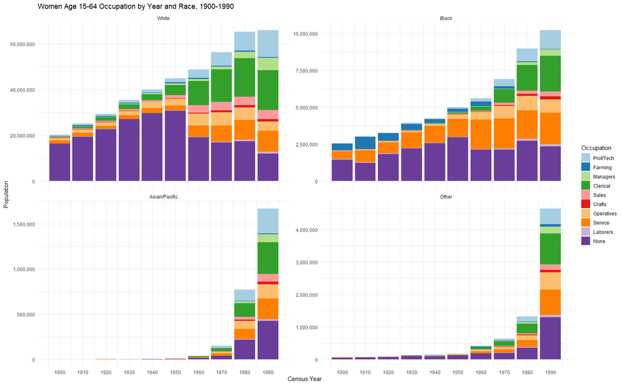

```r
women %>% group_by(YEAR, OCCUP, RACEF) %>% count(wt = PERWT) %>%
  ggplot(aes(YEAR, n, fill = OCCUP)) +
  geom_col() +
  facet_wrap(vars(RACEF), scales = "free_y") +
  scale_fill_brewer(palette = "Paired") +
  theme_minimal() +
  scale_x_continuous(breaks = c(1900, 1910, 1920, 1930, 1940, 1950, 1960, 1970, 1980, 1990)) +
  scale_y_continuous(labels = scales::comma) +
  labs(x = "Census Year", y = "Population", fill = "Occupation", title = "Women Age 15-64 Occupation by Year and Race, 1900-1990")
```

Given how many women were not listed as having an occupation in most of the censuses, it can be hard to see what the women with occupations were doing. Make the same graph again, but this time remove women who were not listed as having an occupation. Do this without changing the `women` data frame.

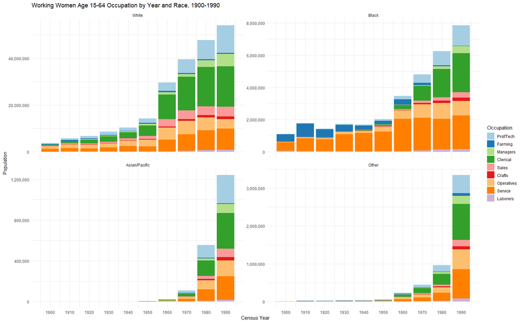

```r
women %>% filter(OCCUP != "None") %>%
  group_by(YEAR, OCCUP, RACEF) %>% count(wt = PERWT) %>%
  ggplot(aes(YEAR, n, fill = OCCUP)) +
  geom_col() +
  facet_wrap(vars(RACEF), scales = "free_y") +
  scale_fill_brewer(palette = "Paired") +
  theme_minimal() +
  scale_x_continuous(breaks = c(1900, 1910, 1920, 1930, 1940, 1950, 1960, 1970, 1980, 1990)) +
  scale_y_continuous(labels = scales::comma) +
  labs(x = "Census Year", y = "Population", fill = "Occupation", title = "Working Women Age 15-64 Occupation by Year and Race, 1900-1990")
```

## Women’s labor force participation

If we eliminate women without an occupational classification from our graph, then we need another graph to indicate what proportion of working-aged women are included in this graph so that readers can also get a sense of the number of women who did not have an occupation listed and how that changed over time. We can do this with a line graph.

What we want is a line graph with `YEAR` on the x-axis and the proportion of women who were listed as having an occupation on the y-axis, with race indicated by line color.

First create a new variable in `women` called `JOB` indicating (true or false) whether each woman had an occupation listed. Test your new variable.

```r
women <- women %>% mutate(JOB = ifelse(OCCUP != "None", 1, 2)) %>% mutate(JOB = factor(JOB, labels = c("True", "False")))

table(women$OCCUP)
```

```
 Prof/Tech    Farming   Managers   Clerical      Sales     Crafts Operatives    Service   Laborers       None
    399306      80083     130865     776930     199455      48308     374735     556296      36764    2432900
```

```r
table(women$JOB)
```

```
   True   False
2602742 2432900
```

Now create a new data frame called `working` that includes one row for each race category in each year, with a column indicating the number of employed women (this will be `n`) and the total number of women (`TOTAL`) in each race category in each year. The code below already includes all of the functions you will need, so you just need to fill in the parentheses.

```r
working <- women %>% group_by(YEAR, RACEF) %>%
                     count(JOB, wt = PERWT) %>%
                     mutate(TOTAL = sum(n)) %>% filter(JOB == "True")

tail(working)
```

| YEAR | RACEF | JOB | n | TOTAL |
| --- | --- | --- | --- | --- |
| 1980 | Asian/Pacific | True | 555000 | 772600 |
| 1980 | Other | True | 959100 | 1322800 |
| 1990 | White | True | 54069871 | 65957270 |
| 1990 | Black | True | 7870393 | 10219732 |
| 1990 | Asian/Pacific | True | 1242778 | 1667625 |
| 1990 | Other | True | 3348343 | 4638831 |

Now make a line graph showing the percentage of women in each race category who were listed as being employed in each year. The year will go on the x-axis, percentage of women will go on the y-axis, and line color will indicate race classification. Make sure the graph is publication quality.

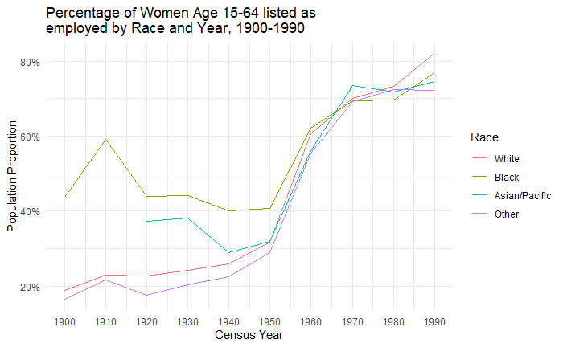

```r
ggplot(working, aes(YEAR, n/TOTAL, color = RACEF)) + geom_line() +
  theme_minimal() +
  scale_x_continuous(breaks = c(1900, 1910, 1920, 1930, 1940, 1950, 1960, 1970, 1980, 1990)) +
  scale_y_continuous(labels = scales::percent) +
  labs(x = "Census Year", y = "Population Proportion", color = "Race", title = "Percentage of Women Age 15-64 listed as \nemployed by Race and Year, 1900-1990")
```

Going back to the `women` data frame, add a column for marital status (`MARITAL`), using the same categories we used in Notebook 5.

```r
women <- women %>% mutate(MARITAL = ifelse(MARST == 6, 1,
                   ifelse(MARST == 1, 2,
                   ifelse(MARST == 5, 4, 3)))) %>%
                   mutate(MARITAL = factor(MARITAL, labels = c("Single", "Married", "Divorsed", "Widowed")))
```

Now go through all of the necessary steps to make a line graph showing the percentage of women in each year who were listed as having an occupation, just as you did before, but this time use color to indicate marital status and facet by race.

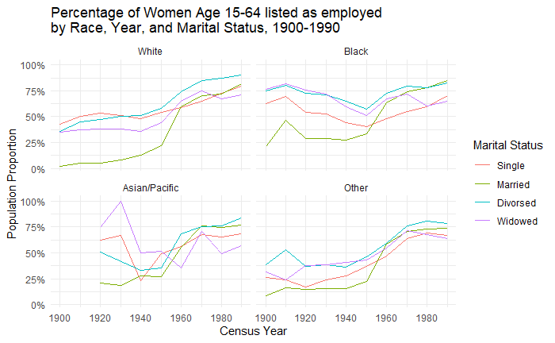

```r
women %>% group_by(YEAR, RACEF, MARITAL) %>%
          count(JOB, wt = PERWT) %>%
          mutate(TOTAL = sum(n)) %>%
          filter(JOB == "True") %>%
          ggplot(aes(YEAR, n/TOTAL, color = MARITAL)) +
            geom_line() +
            facet_wrap(vars(RACEF)) +
            theme_minimal() +
            scale_x_continuous(breaks = c(1900, 1920, 1940, 1960, 1980)) +
            scale_y_continuous(labels = scales::percent) +
            labs(x = "Census Year", y = "Population Proportion", color = "Marital Status", title = "Percentage of Women Age 15-64 listed as employed \nby Race, Year, and Marital Status, 1900-1990")
```

## Women’s households

Now make a graph identical to the previous one, but instead of showing the percent of women aged 15-64 who are listed as having an occupation, show the percent of women aged 15-64 who are listed as household head. Remember that you will need to start by making a variable that indicates whether or not each woman was a head of household.

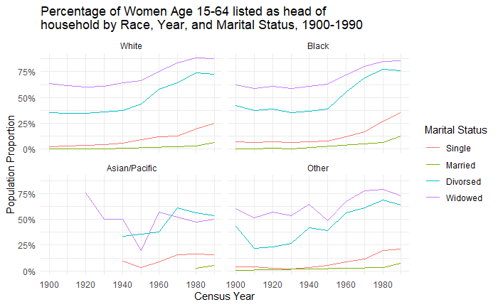

```r
women %>% mutate(HEAD = ifelse(RELATE == 1, RELATE, 2)) %>%
          mutate(HEAD = factor(HEAD, labels = c("True", "False"))) %>%
          group_by(YEAR, RACEF, MARITAL) %>%
          count(HEAD, wt = PERWT) %>%
          mutate(TOTAL = sum(n)) %>%
          filter(HEAD == "True") %>%
          ggplot(aes(YEAR, n/TOTAL, color = MARITAL)) +
            geom_line() +
            facet_wrap(vars(RACEF)) +
            theme_minimal() +
            scale_x_continuous(breaks = c(1900, 1920, 1940, 1960, 1980)) +
            scale_y_continuous(labels = scales::percent) +
            labs(x = "Census Year", y = "Population Proportion", color = "Marital Status", title = "Percentage of Women Age 15-64 listed as head of \nhousehold by Race, Year, and Marital Status, 1900-1990")
```

## Submit the lab

Save this file, preview it to make sure everything is showing up (if it isn’t, try running all the code again), and upload the .nb.html file to Canvas.